# Airline Data Challenge Capital One

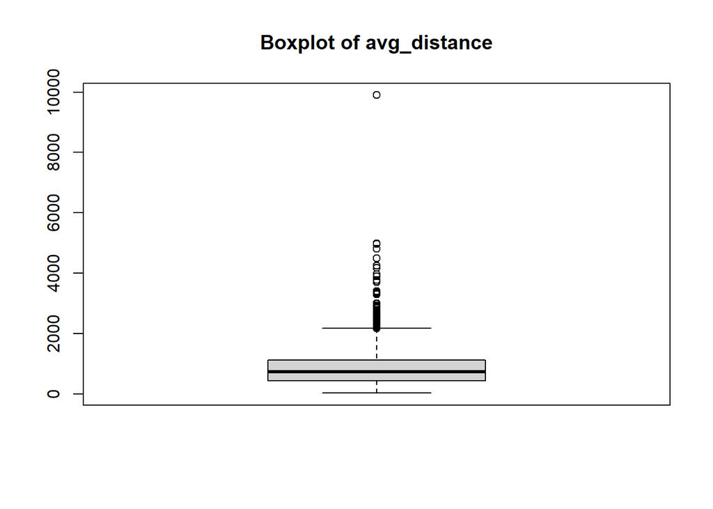

```r
boxplot(dataset_final$avg_distance,main = "Boxplot of avg_distance")
```

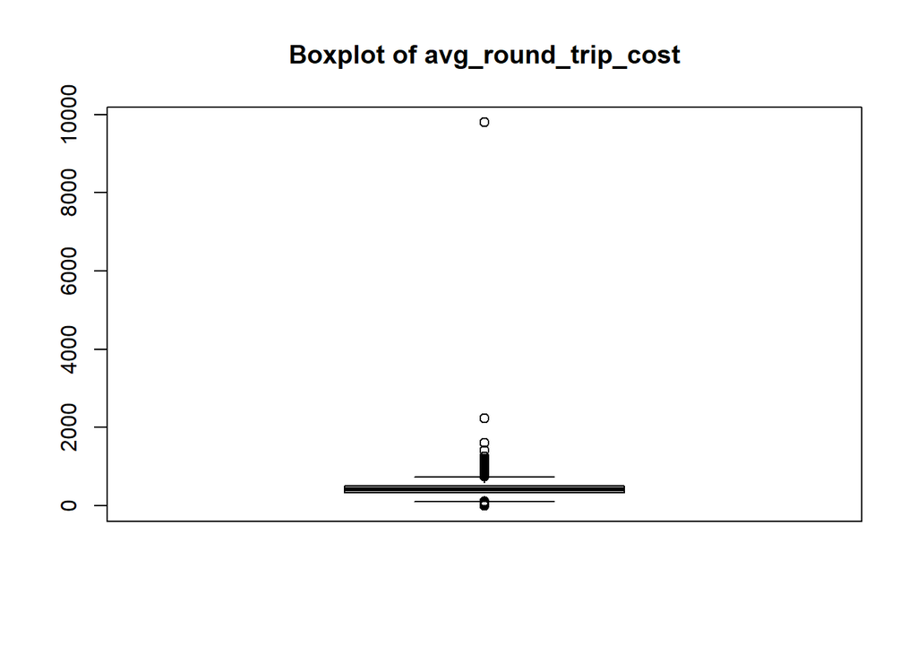

```r
boxplot(dataset_final$avg_round_trip_cost,main = "Boxplot of avg_round_trip_cost")
```

```r
# Detecting and capping outliers using Interquartile range and putting them to new columns

treating_outliers <- function(dataset,column_name) {

qnt <- quantile(unlist(dataset[,column_name]), probs=c(.25, .75), na.rm = T)
iqr <- 2 * IQR(unlist(dataset[,column_name]), na.rm = T)

varname <- paste(column_name,'_capped',sep='')

  dataset <- dataset %>%
    mutate(
           !!varname := round(case_when(!!sym(column_name) >  qnt[2]+iqr ~ qnt[2]+iqr,
                                     !!sym(column_name) <  qnt[1]-iqr ~ qnt[1]-iqr,
                                     !!sym(column_name) <= qnt[2]+iqr
                                   & !!sym(column_name) >= qnt[1]-iqr ~ !!sym(column_name)),2))

  return(dataset)
}


dataset_final <- treating_outliers(dataset_final,'avg_arr_delay_origin')
dataset_final <- treating_outliers(dataset_final,'avg_arr_delay_destination')
dataset_final <- treating_outliers(dataset_final,'avg_dep_delay_origin')
dataset_final <- treating_outliers(dataset_final,'avg_dep_delay_destination')
dataset_final <- treating_outliers(dataset_final,'avg_distance')
dataset_final <- treating_outliers(dataset_final,'avg_round_trip_cost')

# checking summary of data set to see max and 3rd quartile values to see the ranges

summary(dataset_final)
```

```
##     ORIGIN          ORIGIN_CITY_NAME   DESTINATION        DEST_CITY_NAME
##  Length:2828        Length:2828        Length:2828        Length:2828
##  Class :character   Class :character   Class :character   Class :character
##  Mode  :character   Mode  :character   Mode  :character   Mode  :character
##
##
##
##  avg_arr_delay_origin avg_dep_delay_origin  avg_distance    avg_occupancy_rate
##  Min.   :-42.5000     Min.   :-14.500      Min.   :  31.0   Min.   :0.3800
##  1st Qu.: -0.5925     1st Qu.:  5.268      1st Qu.: 433.0   1st Qu.:0.6400
##  Median :  4.1000     Median :  9.395      Median : 737.5   Median :0.6500
##  Mean   :  5.8577     Mean   : 11.228      Mean   : 887.2   Mean   :0.6512
##  3rd Qu.: 10.2700     3rd Qu.: 14.825      3rd Qu.:1131.5   3rd Qu.:0.6600
##  Max.   :216.0000     Max.   :217.000      Max.   :9898.0   Max.   :0.9700
##  high_occupancy_percentage number_of_flights origin_name
##  Min.   :0.0000            Min.   :   1.0    Length:2828
##  1st Qu.:0.3400            1st Qu.:  88.0    Class :character
##  Median :0.3600            Median : 221.5    Mode  :character
##  Mean   :0.3656            Mean   : 324.3
##  3rd Qu.:0.3900            3rd Qu.: 419.0
##  Max.   :1.0000            Max.   :4164.0
##  origin_type        destination_name   destination_type
##  Length:2828        Length:2828        Length:2828
##  Class :character   Class :character   Class :character
##  Mode  :character   Mode  :character   Mode  :character
##
##
##
##  avg_arr_delay_destination avg_dep_delay_destination avg_round_trip_cost
##  Min.   :-41.000           Min.   :-13.340           Min.   :   0.0
##  1st Qu.: -1.200           1st Qu.:  4.758           1st Qu.: 342.1
##  Median :  3.535           Median :  8.950           Median : 416.1
##  Mean   :  4.978           Mean   : 10.371           Mean   : 429.5
##  3rd Qu.:  9.740           3rd Qu.: 14.248           3rd Qu.: 503.1
##  Max.   :200.000           Max.   :218.000           Max.   :9794.8
##  avg_arr_delay_origin_capped avg_arr_delay_destination_capped
##  Min.   :-22.3200            Min.   :-23.080
##  1st Qu.: -0.5925            1st Qu.: -1.200
##  Median :  4.1000            Median :  3.535
##  Mean   :  5.4061            Mean   :  4.683
##  3rd Qu.: 10.2700            3rd Qu.:  9.740
##  Max.   : 31.9900            Max.   : 31.620
##  avg_dep_delay_origin_capped avg_dep_delay_destination_capped
##  Min.   :-13.850             Min.   :-13.340
##  1st Qu.:  5.268             1st Qu.:  4.758
##  Median :  9.395             Median :  8.950
##  Mean   : 10.652             Mean   : 10.043
##  3rd Qu.: 14.825             3rd Qu.: 14.248
##  Max.   : 33.940             Max.   : 33.230
##  avg_distance_capped avg_round_trip_cost_capped
##  Min.   :  31.0      Min.   : 20.23
##  1st Qu.: 433.0      1st Qu.:342.13
##  Median : 737.5      Median :416.14
##  Mean   : 874.3      Mean   :423.71
##  3rd Qu.:1131.5      3rd Qu.:503.08
##  Max.   :2528.5      Max.   :824.98
```

# Calculating cost, revenue and profits of the round trip routes

```r
#From the data and assumptions given the PDF, cost is calculated as follows

# Costs = $8*2*Miles + $1.18*2*Miles + $5,000*Medium + $10,000*Large + (Departure Delay-15)*$75 + (Arrival Delay-15)*75
dataset_final <- dataset_final %>%
  mutate(operating_cost = round(8*2*avg_distance_capped+
                    1.18*2*avg_distance_capped+
                    ifelse(origin_type=='medium_airport',5000,10000)+ifelse(destination_type=='medium_airport',5000,10000)+
                    ifelse(avg_dep_delay_origin_capped-15>0,(avg_dep_delay_origin_capped-15)*75,0)+
                    ifelse(avg_arr_delay_origin_capped-15>0,(avg_arr_delay_origin_capped-15)*75,0)+
                    ifelse(avg_dep_delay_destination_capped-15>0,(avg_dep_delay_destination_capped-15)*75,0)+
                    ifelse(avg_arr_delay_destination_capped-15>0,(avg_arr_delay_destination_capped-15)*75,0),2))

# #From the data and assumptions given the PDF, revenue is calculated as follows

# Revenue = Occupancy*200*Round Trip Price + Occupancy*0.5*200*35(Check-in cost)*2
dataset_final <- dataset_final %>%
  mutate( revenue = round(avg_occupancy_rate*200*avg_round_trip_cost_capped+avg_occupancy_rate*200*0.5*2*35,2))

# Profit = Revenue - Cost
 dataset_final <- dataset_final %>%
  mutate( profit = revenue-operating_cost)
summary(dataset_final)
```

```
##     ORIGIN          ORIGIN_CITY_NAME   DESTINATION        DEST_CITY_NAME
##  Length:2828        Length:2828        Length:2828        Length:2828
##  Class :character   Class :character   Class :character   Class :character
##  Mode  :character   Mode  :character   Mode  :character   Mode  :character
##
##
##
##  avg_arr_delay_origin avg_dep_delay_origin  avg_distance    avg_occupancy_rate
##  Min.   :-42.5000     Min.   :-14.500      Min.   :  31.0   Min.   :0.3800
##  1st Qu.: -0.5925     1st Qu.:  5.268      1st Qu.: 433.0   1st Qu.:0.6400
##  Median :  4.1000     Median :  9.395      Median : 737.5   Median :0.6500
##  Mean   :  5.8577     Mean   : 11.228      Mean   : 887.2   Mean   :0.6512
##  3rd Qu.: 10.2700     3rd Qu.: 14.825      3rd Qu.:1131.5   3rd Qu.:0.6600
##  Max.   :216.0000     Max.   :217.000      Max.   :9898.0   Max.   :0.9700
##  high_occupancy_percentage number_of_flights origin_name
##  Min.   :0.0000            Min.   :   1.0    Length:2828
##  1st Qu.:0.3400            1st Qu.:  88.0    Class :character
##  Median :0.3600            Median : 221.5    Mode  :character
##  Mean   :0.3656            Mean   : 324.3
##  3rd Qu.:0.3900            3rd Qu.: 419.0
##  Max.   :1.0000            Max.   :4164.0
##  origin_type        destination_name   destination_type
##  Length:2828        Length:2828        Length:2828
##  Class :character   Class :character   Class :character
##  Mode  :character   Mode  :character   Mode  :character
##
##
##
##  avg_arr_delay_destination avg_dep_delay_destination avg_round_trip_cost
##  Min.   :-41.000           Min.   :-13.340           Min.   :   0.0
##  1st Qu.: -1.200           1st Qu.:  4.758           1st Qu.: 342.1
##  Median :  3.535           Median :  8.950           Median : 416.1
##  Mean   :  4.978           Mean   : 10.371           Mean   : 429.5
##  3rd Qu.:  9.740           3rd Qu.: 14.248           3rd Qu.: 503.1
##  Max.   :200.000           Max.   :218.000           Max.   :9794.8
##  avg_arr_delay_origin_capped avg_arr_delay_destination_capped
##  Min.   :-22.3200            Min.   :-23.080
##  1st Qu.: -0.5925            1st Qu.: -1.200
##  Median :  4.1000            Median :  3.535
##  Mean   :  5.4061            Mean   :  4.683
```

[output cut: 8 more lines]

```
##  Max.   : 33.940             Max.   : 33.230
##  avg_distance_capped avg_round_trip_cost_capped operating_cost
##  Min.   :  31.0      Min.   : 20.23             Min.   :10569
##  1st Qu.: 433.0      1st Qu.:342.13             1st Qu.:26534
##  Median : 737.5      Median :416.14             Median :32430
##  Mean   : 874.3      Mean   :423.71             Mean   :34754
##  3rd Qu.:1131.5      3rd Qu.:503.08             3rd Qu.:39939
##  Max.   :2528.5      Max.   :824.98             Max.   :69855
##     revenue           profit
##  Min.   :  7069   Min.   :-20970
##  1st Qu.: 48751   1st Qu.: 13590
##  Median : 58725   Median : 24121
##  Mean   : 59788   Mean   : 25034
##  3rd Qu.: 70240   3rd Qu.: 36436
##  Max.   :154558   Max.   : 97024
```

# Analysis of the final data set

Assumptions

The following assumptions from the PDF given for direction are taken into account during the analysis

1. capacity 200 for all the flights which is constant.
2. 50% passengers have check-in luggage.
3. No seasonality. Demand is constant
4. Also as mentioned before, apart from difference in arrival and departure delays in origin and destination, other variables like distance, round trip cost are the same. So, only one row is used.

Metadata

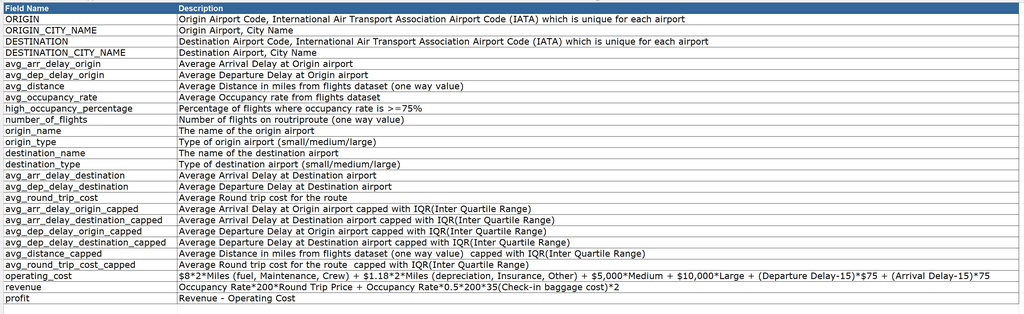

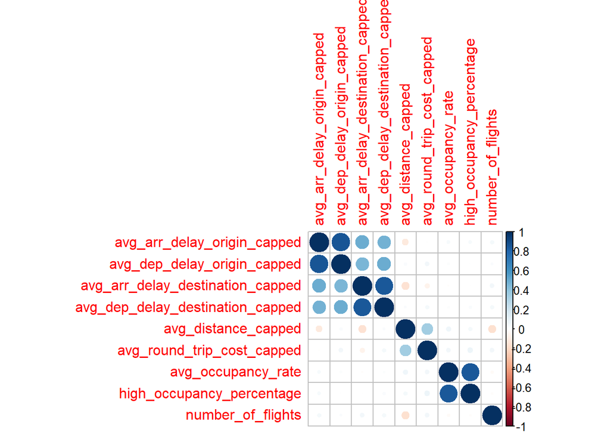

```r
# checking correlation between the numerical variables especially between arrival delay and departure delay in origin and destination


corrplot(cor(dataset_final[,c('avg_arr_delay_origin_capped',
                       'avg_dep_delay_origin_capped','avg_arr_delay_destination_capped',
                               'avg_dep_delay_destination_capped','avg_distance_capped',
                               'avg_round_trip_cost_capped','avg_occupancy_rate','high_occupancy_percentage',
                               'number_of_flights'
)]))
```

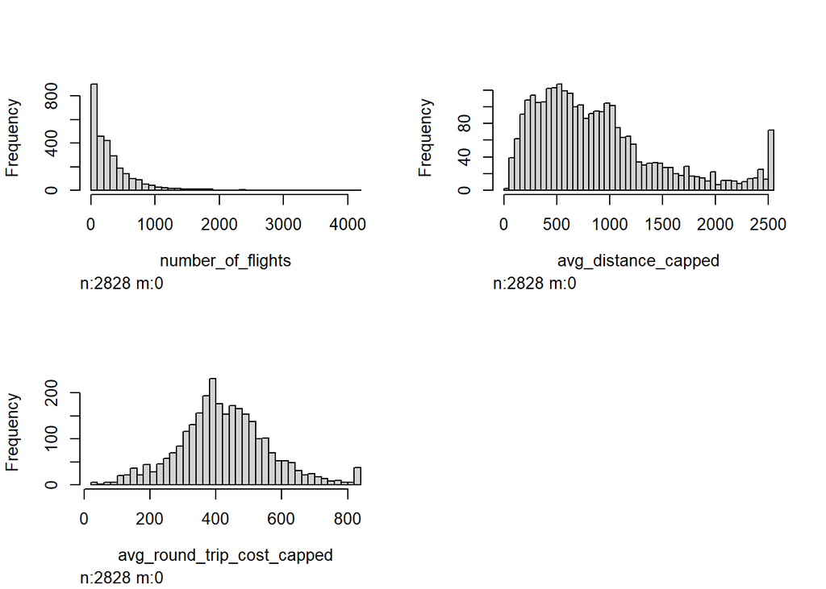

```r
# histogram for number of flights, average distance, round trip costs
hist.data.frame(dataset_final[,c('number_of_flights','avg_distance_capped','avg_round_trip_cost_capped')])
```

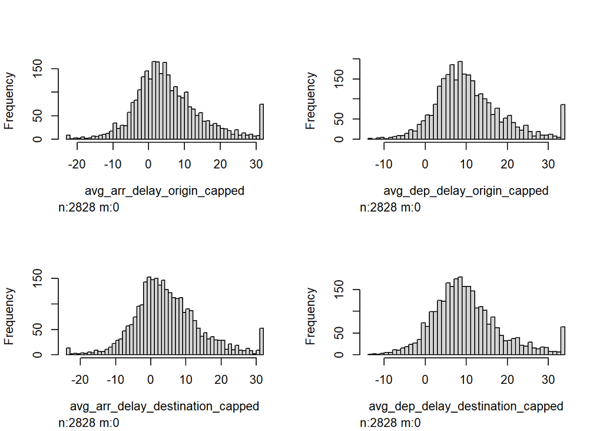

```r
# histogram for delays
hist.data.frame(dataset_final[,c('avg_arr_delay_origin_capped','avg_dep_delay_origin_capped','avg_arr_delay_destination_capped','avg_dep_delay_destination_capped')])
```

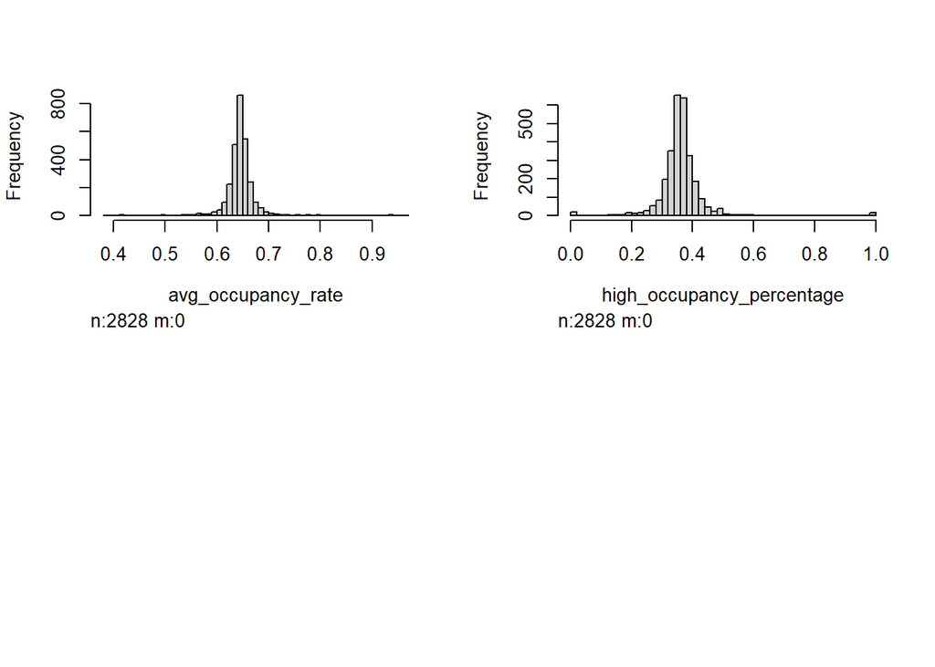

```r
# histogram number occupancy rate and high occupancy Percentage
hist.data.frame(dataset_final[,c('avg_occupancy_rate','high_occupancy_percentage')])
```

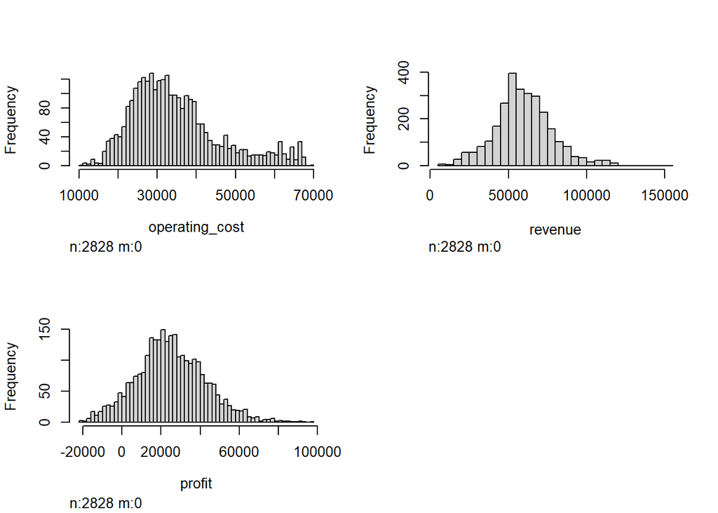

```r
hist.data.frame(dataset_final[,c()])

hist.data.frame(dataset_final[,c('operating_cost','revenue','profit')])
```

```r
dataset_final %>%
  summarise(routes_operating_with_loss = sum(ifelse( profit<0,1,0)),
            routes_with_less_than_10_trips =sum(ifelse( number_of_flights<10,1,0)),
            routes_with_less_than_500_trips =sum(ifelse( number_of_flights<500,1,0)))
```

```
## # A tibble: 1 × 3
##   routes_operating_with_loss routes_with_less_than_10_trips routes_with_less_t…¹
##                        <dbl>                          <dbl>                <dbl>
## 1                        216                             86                 2258
## # … with abbreviated variable name ¹routes_with_less_than_500_trips
```

# Answering the questions

```r
# creating a column for route pair
 dataset_final <- dataset_final %>%
  mutate( Route = paste(ORIGIN,DESTINATION, sep='-'))

# creating reporting dataset contianing required columns

reporting_dataset <- dataset_final %>% select(Route,ORIGIN,ORIGIN_CITY_NAME,origin_type,DESTINATION,DEST_CITY_NAME,destination_type,avg_occupancy_rate,high_occupancy_percentage,number_of_flights,avg_distance_capped,avg_round_trip_cost_capped,operating_cost,revenue,profit,avg_arr_delay_origin_capped,avg_dep_delay_origin_capped,avg_arr_delay_destination_capped,avg_dep_delay_destination_capped)

top_n_bar <- function(data, col1, col2, n, title, xaxis, yaxis){

  col1 <- enquo(col1)

  col2 <- enquo(col2)

  graph_name <- title

  graph_data <- data %>% arrange(desc(!!col2)) %>% head(n)

    graph_data %>%
    ggplot(aes(x = reorder(!!col1, -(!!col2)), y = !!col2, fill = !!col1)) +
    geom_bar(stat = "identity") +
    theme(legend.position = "none", axis.text.x = element_text(size = 5)) +

    labs(x = xaxis, y = yaxis, title = graph_name)

}

top_n_table <- function(data, col1, n, title){

  graph_name = title
  col1 <- enquo(col1)

  data %>% arrange(desc(!!col1)) %>% head(n) %>%
   gt() %>%
   tab_header(title = graph_name)
}
```

## 1. Top 10 routes in terms of number of round trip flights

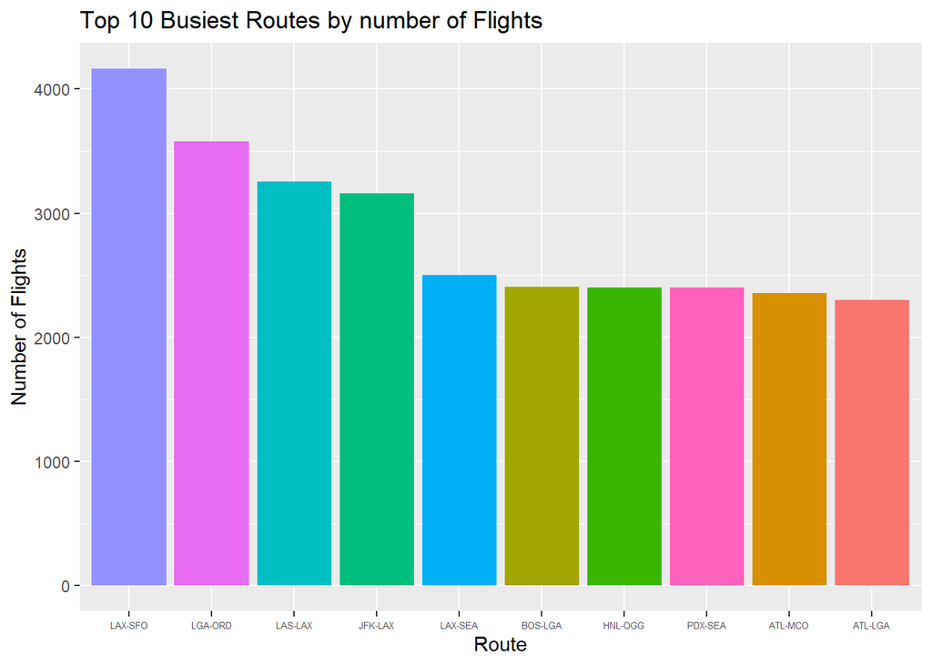

```r
top_n_bar(reporting_dataset,Route,number_of_flights,10, "Top 10 Busiest Routes by number of Flights","Route","Number of Flights")
```

```r
top_n_table(reporting_dataset,number_of_flights,10,"Top 10 Busiest Routes by number of Flights")
```

Top 10 Busiest Routes by number of Flights

| Route | ORIGIN | ORIGIN_CITY_NAME | origin_type | DESTINATION | DEST_CITY_NAME | destination_type | avg_occupancy_rate | high_occupancy_percentage | number_of_flights | avg_distance_capped | avg_round_trip_cost_capped | operating_cost | revenue | profit | avg_arr_delay_origin_capped | avg_dep_delay_origin_capped | avg_arr_delay_destination_capped | avg_dep_delay_destination_capped |
| --- | --- | --- | --- | --- | --- | --- | --- | --- | --- | --- | --- | --- | --- | --- | --- | --- | --- | --- |
| LAX-SFO | LAX | Los Angeles, CA | large_airport | SFO | San Francisco, CA | large_airport | 0.65 | 0.35 | 4164 | 337 | 282.08 | 26874.32 | 41220.40 | 14346.08 | 17.20 | 20.30 | 14.22 | 16.66 |
| LGA-ORD | LGA | New York, NY | large_airport | ORD | Chicago, IL | large_airport | 0.65 | 0.36 | 3576 | 733 | 352.94 | 35104.13 | 50432.20 | 15328.07 | 18.74 | 20.20 | 20.54 | 22.47 |
| LAS-LAX | LAS | Las Vegas, NV | large_airport | LAX | Los Angeles, CA | large_airport | 0.65 | 0.36 | 3254 | 236 | 192.52 | 24332.96 | 29577.60 | 5244.64 | 7.19 | 9.54 | 6.73 | 10.68 |
| JFK-LAX | JFK | New York, NY | large_airport | LAX | Los Angeles, CA | large_airport | 0.65 | 0.36 | 3158 | 2475 | 824.98 | 65441.00 | 111797.40 | 46356.40 | -0.07 | 5.01 | -3.70 | 12.08 |
| LAX-SEA | LAX | Los Angeles, CA | large_airport | SEA | Seattle, WA | large_airport | 0.66 | 0.37 | 2502 | 954 | 362.73 | 37515.44 | 52500.36 | 14984.92 | 1.25 | 7.07 | 7.46 | 8.42 |
| BOS-LGA | BOS | Boston, MA | large_airport | LGA | New York, NY | large_airport | 0.65 | 0.37 | 2405 | 184 | 338.75 | 24128.99 | 48587.50 | 24458.51 | 15.73 | 21.09 | 12.73 | 18.19 |
| HNL-OGG | HNL | Honolulu, HI | large_airport | OGG | Kahului, HI | medium_airport | 0.65 | 0.36 | 2399 | 100 | 289.95 | 16836.00 | 42243.50 | 25407.50 | -0.75 | -0.50 | 0.43 | -0.18 |
| PDX-SEA | PDX | Portland, OR | large_airport | SEA | Seattle, WA | large_airport | 0.65 | 0.37 | 2398 | 129 | 289.63 | 22368.44 | 42201.90 | 19833.46 | 7.59 | 6.34 | 7.83 | 8.82 |
| ATL-MCO | ATL | Atlanta, GA | large_airport | MCO | Orlando, FL | large_airport | 0.65 | 0.36 | 2356 | 404 | 362.03 | 27417.44 | 51613.90 | 24196.46 | 1.28 | 6.99 | 1.54 | 5.39 |
| ATL-LGA | ATL | Atlanta, GA | large_airport | LGA | New York, NY | large_airport | 0.66 | 0.38 | 2301 | 762 | 456.21 | 33990.32 | 64839.72 | 30849.40 | 7.55 | 13.39 | 3.36 | 9.22 |

## 2. Top 10 Profitable routes

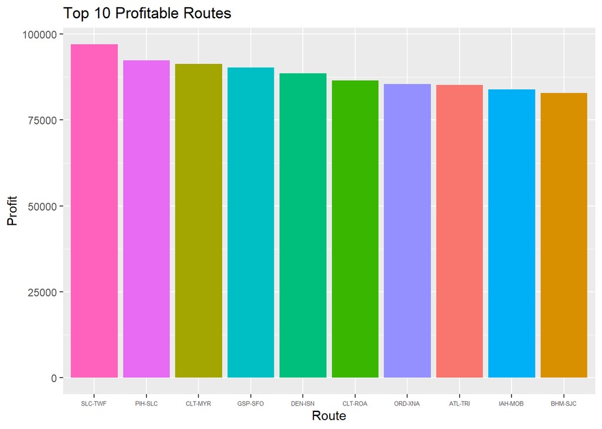

```r
top_n_bar(reporting_dataset,Route,profit,10, "Top 10 Profitable Routes","Route","Profit")
```

```r
top_n_table(reporting_dataset,profit,10,"Top 10 Profitable Routes")
```

Top 10 Profitable Routes

| Route | ORIGIN | ORIGIN_CITY_NAME | origin_type | DESTINATION | DEST_CITY_NAME | destination_type | avg_occupancy_rate | high_occupancy_percentage | number_of_flights | avg_distance_capped | avg_round_trip_cost_capped | operating_cost | revenue | profit | avg_arr_delay_origin_capped | avg_dep_delay_origin_capped | avg_arr_delay_destination_capped | avg_dep_delay_destination_capped |
| --- | --- | --- | --- | --- | --- | --- | --- | --- | --- | --- | --- | --- | --- | --- | --- | --- | --- | --- |
| SLC-TWF | SLC | Salt Lake City, UT | large_airport | TWF | Twin Falls, ID | medium_airport | 0.67 | 0.39 | 257 | 175 | 824.98 | 18213.00 | 115237.3 | 97024.32 | -1.25 | 3.75 | 2.99 | 8.85 |
| PIH-SLC | PIH | Pocatello, ID | medium_airport | SLC | Salt Lake City, UT | large_airport | 0.64 | 0.35 | 270 | 150 | 824.98 | 17754.00 | 110077.4 | 92323.44 | -3.70 | 0.05 | -4.25 | 3.48 |
| CLT-MYR | CLT | Charlotte, NC | large_airport | MYR | Myrtle Beach, SC | medium_airport | 0.64 | 0.34 | 677 | 157 | 818.50 | 17882.52 | 109248.0 | 91365.48 | 0.08 | 4.12 | -4.62 | 2.85 |
| GSP-SFO | GSP | Greer, SC | large_airport | SFO | San Francisco, CA | large_airport | 0.97 | 1.00 | 1 | 2233 | 761.69 | 64293.38 | 154557.9 | 90264.48 | 31.00 | 33.94 | 4.00 | 24.00 |
| DEN-ISN | DEN | Denver, CO | large_airport | ISN | Williston, ND | medium_airport | 0.67 | 0.40 | 321 | 576 | 824.98 | 26692.86 | 115237.3 | 88544.46 | 13.25 | 18.35 | 21.61 | 19.94 |
| CLT-ROA | CLT | Charlotte, NC | large_airport | ROA | Roanoke, VA | large_airport | 0.66 | 0.41 | 595 | 155 | 793.00 | 22845.80 | 109296.0 | 86450.20 | -1.33 | 6.95 | -1.18 | 5.19 |
| ORD-XNA | ORD | Chicago, IL | large_airport | XNA | Fayetteville, AR | medium_airport | 0.64 | 0.36 | 534 | 522 | 824.98 | 24583.92 | 110077.4 | 85493.52 | 10.73 | 12.17 | 2.85 | 7.70 |
| ATL-TRI | ATL | Atlanta, GA | large_airport | TRI | Bristol/Johnson City/Kingsport, TN | large_airport | 0.64 | 0.33 | 486 | 227 | 819.33 | 24167.72 | 109354.2 | 85186.52 | -0.69 | 5.91 | 1.96 | 7.89 |
| IAH-MOB | IAH | Houston, TX | large_airport | MOB | Mobile, AL | large_airport | 0.65 | 0.38 | 416 | 427 | 824.98 | 27839.72 | 111797.4 | 83957.68 | 4.30 | 5.96 | 3.03 | 5.99 |
| BHM-SJC | BHM | Birmingham, AL | large_airport | SJC | San Jose, CA | large_airport | 0.97 | 1.00 | 1 | 1990 | 689.45 | 57661.40 | 140543.3 | 82881.90 | 30.00 | 5.00 | -23.08 | -4.50 |

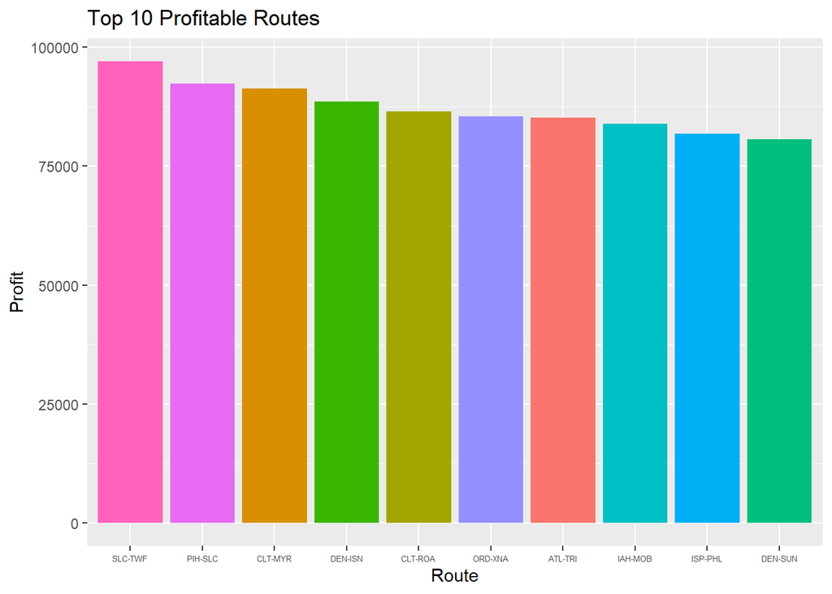

```r
#  When we look at the table two routes (GSP-SFO, BHM-SJC) just have 1 round flight operated. Lets look at the Top 10 profitable routes with atleast 10 flights operated

top_n_bar( reporting_dataset %>% filter(number_of_flights >= 10),Route,profit,10, "Top 10 Profitable Routes","Route","Profit")
```

```r
top_n_table( reporting_dataset %>% filter(number_of_flights >= 10),profit,10,"Top 10 Profitable Routes")
```

Top 10 Profitable Routes

| Route | ORIGIN | ORIGIN_CITY_NAME | origin_type | DESTINATION | DEST_CITY_NAME | destination_type | avg_occupancy_rate | high_occupancy_percentage | number_of_flights | avg_distance_capped | avg_round_trip_cost_capped | operating_cost | revenue | profit | avg_arr_delay_origin_capped | avg_dep_delay_origin_capped | avg_arr_delay_destination_capped | avg_dep_delay_destination_capped |
| --- | --- | --- | --- | --- | --- | --- | --- | --- | --- | --- | --- | --- | --- | --- | --- | --- | --- | --- |
| SLC-TWF | SLC | Salt Lake City, UT | large_airport | TWF | Twin Falls, ID | medium_airport | 0.67 | 0.39 | 257 | 175 | 824.98 | 18213.00 | 115237.3 | 97024.32 | -1.25 | 3.75 | 2.99 | 8.85 |
| PIH-SLC | PIH | Pocatello, ID | medium_airport | SLC | Salt Lake City, UT | large_airport | 0.64 | 0.35 | 270 | 150 | 824.98 | 17754.00 | 110077.4 | 92323.44 | -3.70 | 0.05 | -4.25 | 3.48 |
| CLT-MYR | CLT | Charlotte, NC | large_airport | MYR | Myrtle Beach, SC | medium_airport | 0.64 | 0.34 | 677 | 157 | 818.50 | 17882.52 | 109248.0 | 91365.48 | 0.08 | 4.12 | -4.62 | 2.85 |
| DEN-ISN | DEN | Denver, CO | large_airport | ISN | Williston, ND | medium_airport | 0.67 | 0.40 | 321 | 576 | 824.98 | 26692.86 | 115237.3 | 88544.46 | 13.25 | 18.35 | 21.61 | 19.94 |
| CLT-ROA | CLT | Charlotte, NC | large_airport | ROA | Roanoke, VA | large_airport | 0.66 | 0.41 | 595 | 155 | 793.00 | 22845.80 | 109296.0 | 86450.20 | -1.33 | 6.95 | -1.18 | 5.19 |
| ORD-XNA | ORD | Chicago, IL | large_airport | XNA | Fayetteville, AR | medium_airport | 0.64 | 0.36 | 534 | 522 | 824.98 | 24583.92 | 110077.4 | 85493.52 | 10.73 | 12.17 | 2.85 | 7.70 |
| ATL-TRI | ATL | Atlanta, GA | large_airport | TRI | Bristol/Johnson City/Kingsport, TN | large_airport | 0.64 | 0.33 | 486 | 227 | 819.33 | 24167.72 | 109354.2 | 85186.52 | -0.69 | 5.91 | 1.96 | 7.89 |
| IAH-MOB | IAH | Houston, TX | large_airport | MOB | Mobile, AL | large_airport | 0.65 | 0.38 | 416 | 427 | 824.98 | 27839.72 | 111797.4 | 83957.68 | 4.30 | 5.96 | 3.03 | 5.99 |
| ISP-PHL | ISP | Islip, NY | medium_airport | PHL | Philadelphia, PA | large_airport | 0.63 | 0.35 | 167 | 130 | 752.00 | 17386.80 | 99162.0 | 81775.20 | 4.88 | 5.71 | 5.06 | 4.20 |
| DEN-SUN | DEN | Denver, CO | large_airport | SUN | Sun Valley/Hailey/Ketchum, ID | medium_airport | 0.65 | 0.37 | 87 | 557 | 779.67 | 25226.52 | 105907.1 | 80680.58 | -4.07 | 9.56 | 2.98 | 3.69 |

## 3. Recommendations on investing in top routes

```r
flights_to_invest_in <- reporting_dataset %>%
  mutate(quartile_number_of_flights = ntile(number_of_flights, 4),
         quartile_avg_occupancy_rate = ntile(avg_occupancy_rate, 4),
         quartile_high_occupancy_percentage = ntile(high_occupancy_percentage, 4),
         quartile_profit = ntile(profit, 4),
         quartile_delays = ntile(avg_arr_delay_origin_capped+avg_dep_delay_origin_capped+avg_arr_delay_destination_capped+avg_dep_delay_destination_capped, 4))  %>%
    filter(quartile_number_of_flights == 4 & quartile_avg_occupancy_rate == 4 & quartile_high_occupancy_percentage == 4 & quartile_profit == 4 & (quartile_delays == 1 |quartile_delays == 2 |quartile_delays == 3))

top_n_table(flights_to_invest_in,Route,6,"Routes to Invest In")
```

Routes to Invest In

| Route | ORIGIN | ORIGIN_CITY_NAME | origin_type | DESTINATION | DEST_CITY_NAME | destination_type | avg_occupancy_rate | high_occupancy_percentage | number_of_flights | avg_distance_capped | avg_round_trip_cost_capped | operating_cost | revenue | profit | avg_arr_delay_origin_capped | avg_dep_delay_origin_capped | avg_arr_delay_destination_capped | avg_dep_delay_destination_capped | quartile_number_of_flights | quartile_avg_occupancy_rate | quartile_high_occupancy_percentage | quartile_profit | quartile_delays |
| --- | --- | --- | --- | --- | --- | --- | --- | --- | --- | --- | --- | --- | --- | --- | --- | --- | --- | --- | --- | --- | --- | --- | --- |
| IAH-PIT | IAH | Houston, TX | large_airport | PIT | Pittsburgh, PA | large_airport | 0.66 | 0.39 | 436 | 1117 | 613.58 | 40508.12 | 85612.56 | 45104.44 | -7.73 | 3.55 | -1.30 | -0.88 | 4 | 4 | 4 | 4 | 1 |
| IAH-LFT | IAH | Houston, TX | large_airport | LFT | Lafayette, LA | large_airport | 0.67 | 0.39 | 534 | 201 | 447.22 | 23690.36 | 64617.48 | 40927.12 | 8.26 | 7.84 | 3.29 | 4.67 | 4 | 4 | 4 | 4 | 2 |
| DTW-ELM | DTW | Detroit, MI | large_airport | ELM | Elmira/Corning, NY | medium_airport | 0.68 | 0.44 | 422 | 332 | 558.00 | 21550.02 | 80648.00 | 59097.98 | 11.11 | 21.06 | 1.02 | 8.31 | 4 | 4 | 4 | 4 | 3 |
| CLT-PBI | CLT | Charlotte, NC | large_airport | PBI | West Palm Beach/Palm Beach, FL | large_airport | 0.67 | 0.41 | 506 | 590 | 633.25 | 30832.40 | 89545.50 | 58713.10 | 6.75 | 9.01 | 1.70 | 5.76 | 4 | 4 | 4 | 4 | 2 |
| ATL-PNS | ATL | Atlanta, GA | large_airport | PNS | Pensacola, FL | medium_airport | 0.67 | 0.40 | 625 | 271 | 523.15 | 19975.56 | 74792.10 | 54816.54 | 3.81 | 9.51 | 1.25 | 8.01 | 4 | 4 | 4 | 4 | 2 |
| ATL-HPN | ATL | Atlanta, GA | large_airport | HPN | White Plains, NY | medium_airport | 0.67 | 0.41 | 460 | 780 | 465.03 | 29320.80 | 67004.02 | 37683.22 | 2.09 | 8.86 | 0.50 | 8.89 | 4 | 4 | 4 | 4 | 2 |

## 4. Number of Round trips taken to break even airplane cost of $90 million

Also, calculating the time required to break even assuming daily round trips for all the routes

```r
flights_to_invest_in <- flights_to_invest_in %>% mutate(round_trips_taken_to_break_even = round(90000000/profit,0),
             years_to_break_even = round(90000000/(profit*7*4*12),0))

top_n_table(flights_to_invest_in,Route,6,"Reccommended Routes to Invest In")
```

Reccommended Routes to Invest In

| Route | ORIGIN | ORIGIN_CITY_NAME | origin_type | DESTINATION | DEST_CITY_NAME | destination_type | avg_occupancy_rate | high_occupancy_percentage | number_of_flights | avg_distance_capped | avg_round_trip_cost_capped | operating_cost | revenue | profit | avg_arr_delay_origin_capped | avg_dep_delay_origin_capped | avg_arr_delay_destination_capped | avg_dep_delay_destination_capped | quartile_number_of_flights | quartile_avg_occupancy_rate | quartile_high_occupancy_percentage | quartile_profit | quartile_delays | round_trips_taken_to_break_even | years_to_break_even |
| --- | --- | --- | --- | --- | --- | --- | --- | --- | --- | --- | --- | --- | --- | --- | --- | --- | --- | --- | --- | --- | --- | --- | --- | --- | --- |
| IAH-PIT | IAH | Houston, TX | large_airport | PIT | Pittsburgh, PA | large_airport | 0.66 | 0.39 | 436 | 1117 | 613.58 | 40508.12 | 85612.56 | 45104.44 | -7.73 | 3.55 | -1.30 | -0.88 | 4 | 4 | 4 | 4 | 1 | 1995 | 6 |
| IAH-LFT | IAH | Houston, TX | large_airport | LFT | Lafayette, LA | large_airport | 0.67 | 0.39 | 534 | 201 | 447.22 | 23690.36 | 64617.48 | 40927.12 | 8.26 | 7.84 | 3.29 | 4.67 | 4 | 4 | 4 | 4 | 2 | 2199 | 7 |
| DTW-ELM | DTW | Detroit, MI | large_airport | ELM | Elmira/Corning, NY | medium_airport | 0.68 | 0.44 | 422 | 332 | 558.00 | 21550.02 | 80648.00 | 59097.98 | 11.11 | 21.06 | 1.02 | 8.31 | 4 | 4 | 4 | 4 | 3 | 1523 | 5 |
| CLT-PBI | CLT | Charlotte, NC | large_airport | PBI | West Palm Beach/Palm Beach, FL | large_airport | 0.67 | 0.41 | 506 | 590 | 633.25 | 30832.40 | 89545.50 | 58713.10 | 6.75 | 9.01 | 1.70 | 5.76 | 4 | 4 | 4 | 4 | 2 | 1533 | 5 |
| ATL-PNS | ATL | Atlanta, GA | large_airport | PNS | Pensacola, FL | medium_airport | 0.67 | 0.40 | 625 | 271 | 523.15 | 19975.56 | 74792.10 | 54816.54 | 3.81 | 9.51 | 1.25 | 8.01 | 4 | 4 | 4 | 4 | 2 | 1642 | 5 |
| ATL-HPN | ATL | Atlanta, GA | large_airport | HPN | White Plains, NY | medium_airport | 0.67 | 0.41 | 460 | 780 | 465.03 | 29320.80 | 67004.02 | 37683.22 | 2.09 | 8.86 | 0.50 | 8.89 | 4 | 4 | 4 | 4 | 2 | 2388 | 7 |

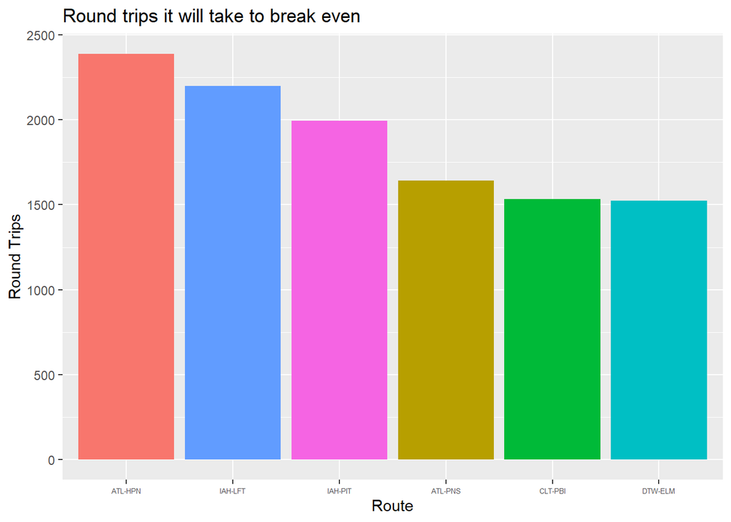

```r
top_n_bar(flights_to_invest_in,Route,round_trips_taken_to_break_even,6, "Round trips it will take to break even","Route","Round Trips")
```

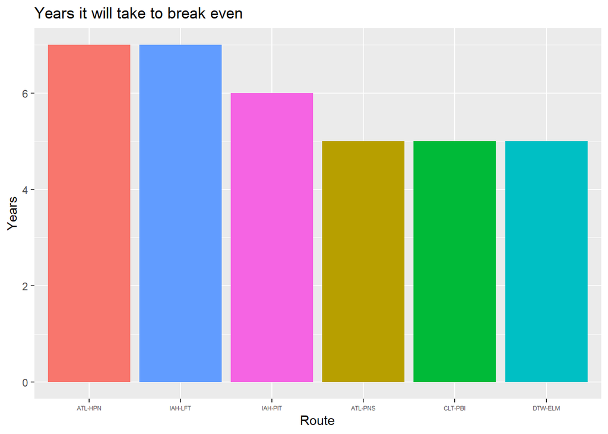

```r
top_n_bar(flights_to_invest_in,Route,years_to_break_even,6, "Years it will take to break even","Route","Years")
```

```r
flights_to_invest_in %>%
              summarise(avg_round_trips=mean(number_of_flights),
                        avg_profit=mean(profit),
                        avg_round_trips_to_break_even=mean(round_trips_taken_to_break_even),
                        avg_years_to_break_even = mean(years_to_break_even))
```

```
## # A tibble: 1 × 4
##   avg_round_trips avg_profit avg_round_trips_to_break_even avg_years_to_break_…¹
##             <dbl>      <dbl>                         <dbl>                 <dbl>
## 1            497.     49390.                          1880                  5.83
## # … with abbreviated variable name ¹avg_years_to_break_even
```

### Insights

On these six recommended routes 497 flights are operated on an average with an average profit of $49,390.It will take the business average of 1880 routes to be operated on these routes. Assuming that, there are 1 daily round trips are operated on these routes with 7 flights a week, it will take 5.8 years years to break-even on flight costs of all these routes. This set of routes are recommended with a view on reducing the risks of low occupancy rate, low occupancy percentage and high delays and increasing the profits. Recommendations will differ if the business wants to opt for a different strategy. Based on the strategic preferences of the business the metrics used to arrive at these recommendations can be tweaked to created a weighted score metric and a different set of routes could be proposed based on that weighted score metric.

## 5. KPIs to be tracked

To gauge the success of our selected route set we should track the following KPIs

Operating cost - In real world operating costs tend to fluctuate. Tracking this will helps understand the factors influencing the costs such as jet fuel expenses , labor costs. It will also help us identify those factors affecting operating costs which was previously not taken into consideration.

Occupancy rate - Occupancy rates need to be tracked and bench marked against average occupancy rates of other airlines in the same routes. Low occupancy rates could be indicative of poor airline performance

Average arrival and departure delays Delay free air travel is what everyone aims for. Departure and arrival delay can increase operating costs and also reduce customer satisfaction. Reasons for delay can also be added to see if external factors like weather, airport constructions are effecting performances.

Ticket prices Dynamic pricing is followed in airline industry and tracking average round trip prices of competitors will help us price our tickets in an optimum manner and help us position our services and attract appropriate customers.

Market share vs Demand Market share helps us understand how much of the demand are we catering to. This can be analyzed with occupancy rate to see if we are capturing targeted market share. We could also use other airlines market share to identify if the demand is more than the supply so that frequency in the routes can be increased.

Total Ticket Bookings: We can track the total tickets booked and measure it against cancelled tickets and the occupancy of the routes

Cancellation rates: This can be monitored and benchmark against cancellations across all the careers to assess aircraft performance

In addition to these metrics, revenue and profit can be tracked too

# Next Steps

1. Using the KPIs that have been suggested, we need to track the performance of airlines on these routes and closely follow demand and fluctuations in demand. By knowing the fluctuations in demand we can alter our schedules and if there are routes which are operating in losses, new routes should be identified based on current demand by using a pivot strategy.
2. Taking seasonality into account will help us make an better informed decision in better scheduling our routes and the frequency of these routes.We also closely need to monitor our competitors in these routes by tracking the frequency of their operations in these routes. Gathering competitor data can help us identify new demands, new customer segments and new markets that have still not been tapped and use it to our advantage in making decisions.
3. Fuel is a very big cost component of operating cost. We need to start gathering data points that affect fuel consumption such airport elevation, average load of the aircraft, average optimum flying altitude of aircraft in these routes to better predict the fuel consumption and forecast operating costs efficiently.
4. We can use the total ticket bookings data and compare them against cancellations and occupancy rate of routes to see if we are utilizing the maximum possible over booking threshold and maximize our profits. If bookings are scares but the demand is high, we need to devise an customer acquisition strategy to attract more customers

Back to top